# 3D graphics and Data Visualisation

## 4. Setting up viewpoints for `rgl` plots

{: #view}

The default viewpoint orientation for rgl plots is not ideal, therefore its important for us to change the viewpoints ourselves.

### Changing the viewpoints

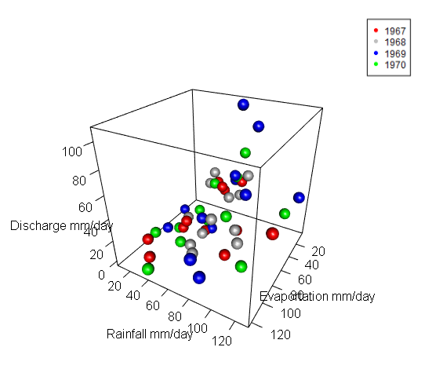

theta and phi are the polar coordinates, to adjust the orientation of viewpoints, we need to change theta and phi.

```r
rgl.viewpoint(theta = 30, phi = 30) #Changing the viewpoint angles

rgl.snapshot("viewpoint.png") #taking screenshot of the device

rgl.close() #closing the current device
```

### Zooming in or out

#### Zoomed in

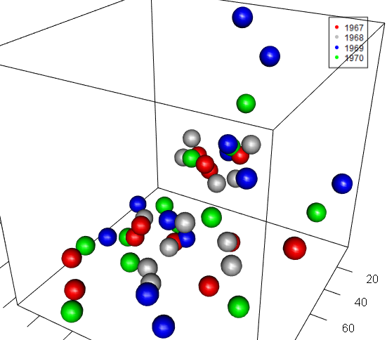

#### Zoomed out

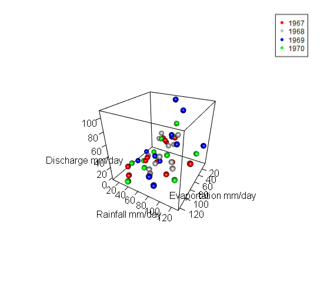

To zoom in or out, all we have to do is add `zoom =` in the `rgl.viewpoint()` function. This is based on a zoom factor, so to zoom in, pick a value below 1, and to zoom out, pick a value above 1.

```r
#Zooming in
rgl.viewpoint(theta = 30, phi = 30, zoom = 0.5)

rgl.snapshot("zoomin.png") #taking screenshot of the device

rgl.close() #closing the current device

#Zooming out
rgl.viewpoint(theta = 30, phi = 30, zoom = 1.5)

rgl.snapshot("zoomout.png") #taking screenshot of the device

rgl.close() #closing the current device
```

## 5. Displaying an interactive `rgl` plot in an R Markdown document

{: #display}

A very important feature of the `rgl` package that makes it stands out from other 3D plotting packages is its interactiveness. the `rglwidget()` function allows the plot to be embedded interactively in a rmarkdown file. Also note that the interactive plots only work when the output format is .HTML.

```r
rglwidget(elementId = "plot")
```

You can then save the interactive plot as an .HTML file.

```
htmlwidgets::saveWidget(rglwidget(),
                        file = "3dscatter.html",
                        selfcontained = FALSE)
```

[interactive chart not shown]

### You can contact us with any questions on ourcodingclub@gmail.com

### Related tutorials:

- [Intro to github for version control](https://ourcodingclub.github.io/tutorials/git/)
- [Coding etiquette](https://ourcodingclub.github.io/tutorials/etiquette/)
- [Basic guide to data manipulation](https://ourcodingclub.github.io/tutorials/data-manip-intro/)
- [Basic guide to data visualisation](https://ourcodingclub.github.io/tutorials/datavis/)
- [Creating interactive web apps using shiny](https://ourcodingclub.github.io/tutorials/shiny/)

### [Follow our coding adventures on Twitter!](https://twitter.com/our_codingclub)